# Patrick’s Shop Network: A Scheduling Playbook

Where Your Time Is Worth the Most

Published

May 13, 2026

## The Short Answer

After reviewing **250 days of productivity records** across five locations, the data points to one clear conclusion:

> **Patrick’s presence has the largest measurable impact at Shop 4 and Shop 2. Shops 5 and 1 also respond well. Shop 3 shows the smallest boost in the data collected so far and should be treated as the lowest scheduling priority until more observations are gathered.**

This report walks through the numbers, explains the uncertainty honestly, and ends with a concrete weekly schedule.

## What the Data Shows

Every dot below is one workday. **Red = Patrick was on-site. Blue = he wasn’t.** The horizontal lines show each group’s average.

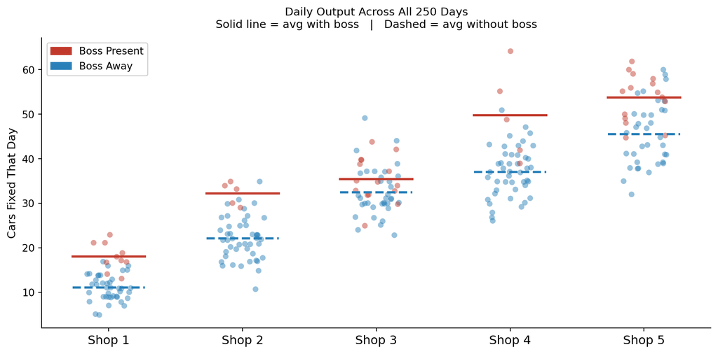

Figure 1: All 250 recorded workdays. Red dots = boss present, blue = boss away. Lines show group averages.

Three things are visible right away:

- Shops 4 and 5 produce the most cars per day regardless of whether Patrick is there.
- The **gap between red and blue averages is widest at Shops 4 and 2** — that gap is the value of a visit.
- At Shop 3, the two lines are closer together, suggesting a smaller boost in this dataset.

## Which Shops Benefit Most?

The “boss boost” measures how many extra cars get fixed, on average, when Patrick is present versus absent at each shop.

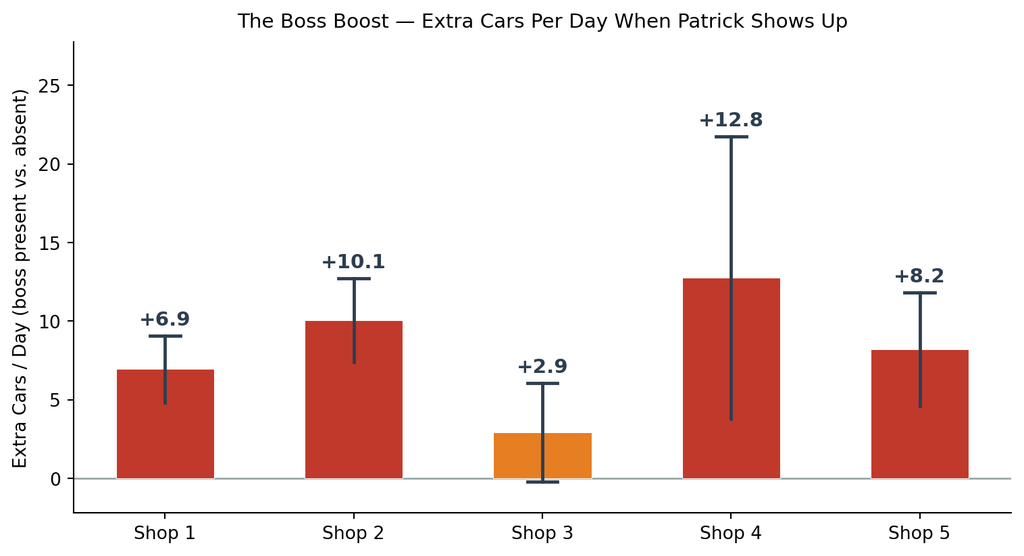

Figure 2: Average extra cars per day when Patrick is on-site. Error bars show the 95% plausible range.

Here is the ranked picture:

| Rank | Shop | Extra Cars/Day | Revenue Boost/Day | Signal Strength |
| --- | --- | --- | --- | --- |
| 1 | **Shop 4** | +12.8 | +$1,920 | Strong |
| 2 | **Shop 2** | +10.1 | +$1,515 | Strong |
| 3 | **Shop 5** | +8.2 | +$1,230 | Good |
| 4 | **Shop 1** | +6.9 | +$1,035 | Good |
| 5 | Shop 3 | +2.9 | +$435 | Uncertain |

*Revenue assumes $150 per car fixed.*

Shop 3 does show a positive number, but the confidence interval is wide enough that the true boost could be close to zero. That’s not a signal to stop visiting — it’s a signal not to prioritize Shop 3 over the others.

## How Confident Should Patrick Be?

The chart below shows the **plausible range** for each shop’s boost. The dot is the best estimate; the bar shows how far off that estimate could reasonably be.

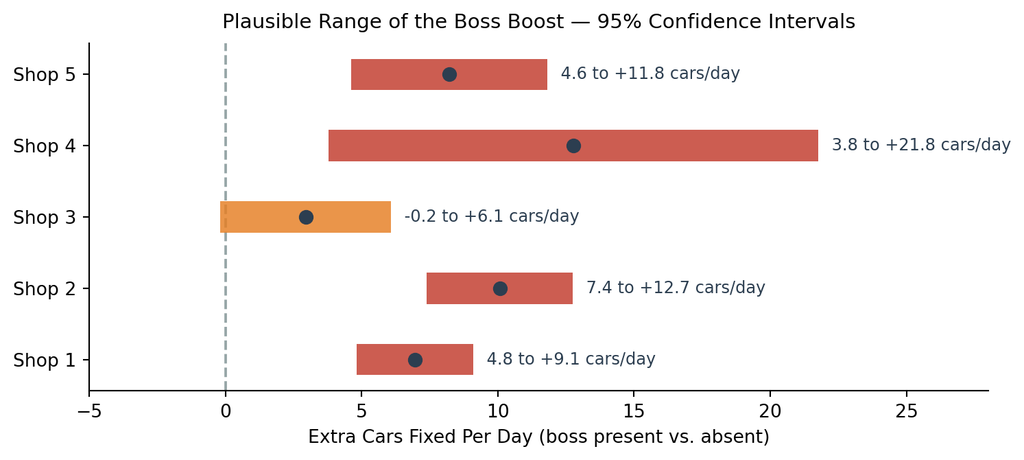

Figure 3: Plausible ranges for each shop’s boost. Bars fully to the right of zero = reliable gains.

## Recommended Weekly Schedule

One shop per day, five days a week — here is how to get the most from every visit:

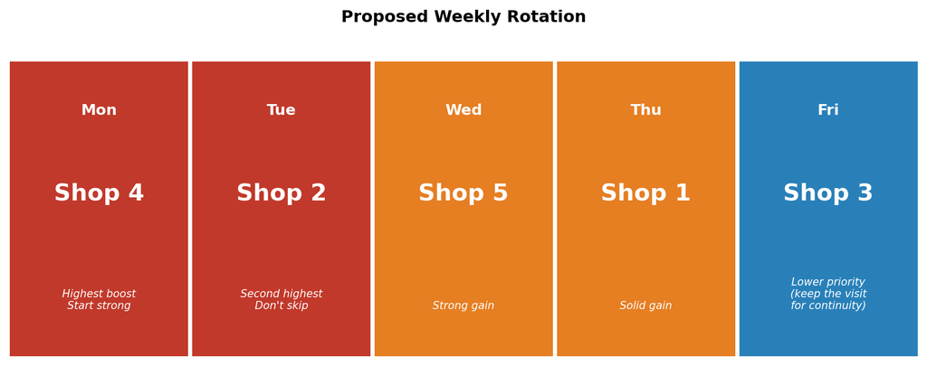

Figure 4: Proposed weekly rotation — highest-impact shops earlier in the week.

Putting Shops 4 and 2 early in the week means the highest-value visits happen before schedule disruptions can push them out.

## What Could This Mean for Revenue?

The chart below compares three approaches across the **250-day window** in the dataset. These are not forecasts — they show what each strategy would have produced historically, based on the observed averages.

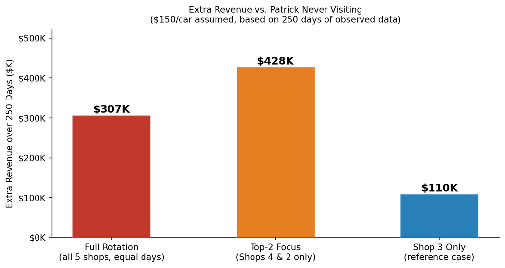

Figure 5: Estimated extra revenue over 250 days under three scheduling approaches.

Key findings:

- A **balanced 5-shop rotation** (one shop per day, equal time at each) would have produced an estimated **$307K** in extra revenue over 250 days compared to Patrick never visiting — purely from the productivity lift his presence creates.
- A **top-2 focus** on Shops 4 and 2 produces more revenue per boss-day, but leaves the other three shops without visits, which may create its own long-term costs.
- **Shop 3 only** is shown as a reference point to illustrate the cost of concentrating visits at the lowest-impact location.

## Risks and Assumptions

**The data covers one time window.** Shop performance can change with new staff, seasonal demand, or a nearby competitor. These findings should be reviewed once a year.

**Revenue is estimated at $150 per car.** If pricing varies by shop or job type, the dollar figures will shift. The *ranking* of shops is not affected by this assumption.

**Presence is not the only lever.** Patrick on-site likely improves output through morale, quality control, and faster decision-making. The data can’t isolate which factor matters most. A strong new manager at Shop 4 might reduce how much his visits contribute there over time.

**Shop 3’s result is the least conclusive.** Fifteen boss-days at Shop 3 is not a large sample. The estimated boost is positive but uncertain. This does not mean Shop 3 is unimportant — it means the data collected so far supports treating it as a lower scheduling priority, not eliminating visits entirely.

## Action Plan

*Analysis based on 250 days of daily productivity records across five locations. Revenue projections assume a fixed rate of $150 per car and do not account for variable costs or staffing changes. Confidence intervals calculated using a two-sample Welch method.*